# Introduction to Statistical Learning Chapter 6 Problem 9

Robert Smith

8/3/2017

9. In this exercise, we will predict the number of applications received using the other variables in the College data set.
1. Split the data set into a training set and a test set.

```r
library(ISLR)
data(College)

set.seed(1234)
obs<-nrow(College)
train_obs<-sample(1:obs,obs*.7)
train_set<-College[train_obs,]
test_set<-College[-train_obs,]
```

2. Fit a linear model using least squares on the training set, and report the test error obtained.

```r
lm_model<-lm(Apps~.,data=train_set)
test_results<-predict(lm_model,test_set)
lm.err<-mean((test_results-test_set$Apps)^2)
lm.err
```

```
## [1] 1108360
```

3. Fit a ridge regression model on the training set, with λ chosen by cross-validation. Report the test error obtained.

```r
library(glmnet)
```

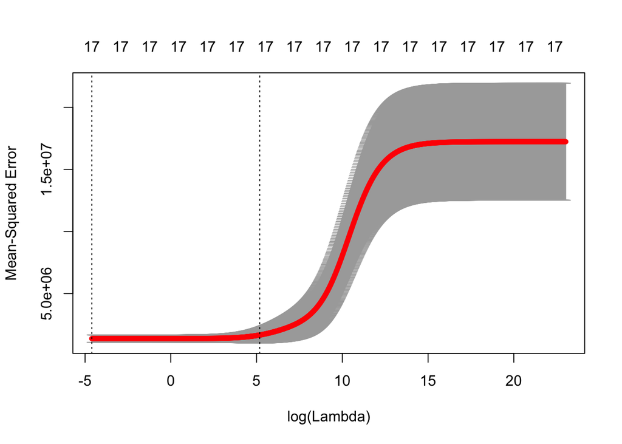

```r
X_train<-model.matrix(Apps~.,data=train_set)[,-1]
X_test<-model.matrix(Apps~.,data=test_set)[,-1]

set.seed(1234)
grid=10^seq(10,-2,length=1000)
cv.ridge.mod=cv.glmnet(X_train,train_set[,"Apps"],alpha=0,lambda=grid,thresh=1e-12)

plot(cv.ridge.mod)
```

```r
bestlam<-cv.ridge.mod$lambda.min
bestlam
```

```
## [1] 0.01
```

Test Error:

```r
ridge_pred<-predict(cv.ridge.mod,s=bestlam,newx=X_test)
ridge.err<-mean((ridge_pred-test_set[,"Apps"])^2)
ridge.err
```

```
## [1] 1108341
```

4. Fit a lasso model on the training set, with λ chosen by cross- validation. Report the test error obtained, along with the num- ber of non-zero coefficient estimates.

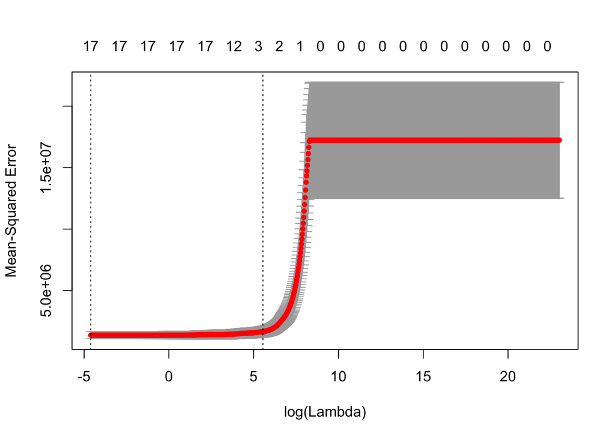

```r
set.seed(1234)
grid=10^seq(10,-2,length=1000)
cv.lasso.mod=cv.glmnet(X_train,train_set[,"Apps"],alpha=1,lambda=grid,thresh=1e-12)

plot(cv.lasso.mod)
```

```r
bestlam<-cv.lasso.mod$lambda.min
bestlam
```

```
## [1] 0.01
```

Test Error & Coefficients:

```r
lasso_pred<-predict(cv.lasso.mod,s=bestlam,newx=X_test)
lasso.err<-mean((lasso_pred-test_set[,"Apps"])^2)
lasso.err
```

```
## [1] 1108292
```

```r
lasso_coef=predict(cv.lasso.mod,type="coefficients",s=bestlam)
print(lasso_coef)
```

```
## 18 x 1 sparse Matrix of class "dgCMatrix"
##                         1
## (Intercept) -1.020366e+03
## PrivateYes  -4.397169e+02
## Accept       1.631250e+00
## Enroll      -1.167228e+00
## Top10perc    4.910220e+01
## Top25perc   -1.277640e+01
## F.Undergrad  8.921211e-02
## P.Undergrad  5.663830e-02
## Outstate    -1.092639e-01
## Room.Board   1.586569e-01
## Books        8.095973e-02
## Personal     8.840135e-02
## PhD         -6.537429e+00
## Terminal    -5.733075e+00
## S.F.Ratio    3.300053e+01
## perc.alumni  6.302140e+00
## Expend       1.072708e-01
## Grad.Rate    8.105162e+00
```

5. Fit a PCR model on the training set, with M chosen by cross- validation. Report the test error obtained, along with the value of M selected by cross-validation.

```r
library(pls)
```

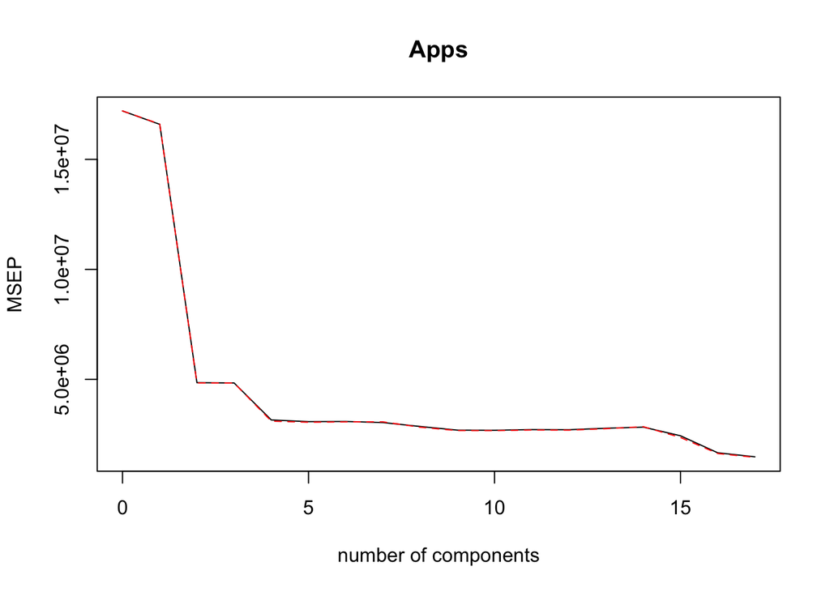

```r
set.seed(1234)
pcr.fit<-pcr(Apps~.,data=train_set,scale=T,validation="CV")

validationplot(pcr.fit,val.type="MSEP")
```

```r
pcr.pred<-predict(pcr.fit,test_set,ncomp=17)
pcr.err<-mean((pcr.pred-test_set$Apps)^2)
pcr.err
```

```
## [1] 1108360
```

6. Fit a PLS model on the training set, with M chosen by cross- validation. Report the test error obtained, along with the value of M selected by cross-validation.

```r
set.seed(1234)
pls.fit<-plsr(Apps~.,data=train_set,scale=T,validation="CV")
summary(pls.fit)
```

```
## Data:    X dimension: 543 17
##  Y dimension: 543 1
## Fit method: kernelpls
## Number of components considered: 17
##
## VALIDATION: RMSEP
## Cross-validated using 10 random segments.
##        (Intercept)  1 comps  2 comps  3 comps  4 comps  5 comps  6 comps
## CV            4147     2016     1749     1571     1519     1338     1274
## adjCV         4147     2011     1746     1564     1499     1317     1261
##        7 comps  8 comps  9 comps  10 comps  11 comps  12 comps  13 comps
## CV        1245     1240     1228      1226      1221      1218      1216
## adjCV     1234     1229     1216      1215      1210      1207      1205
##        14 comps  15 comps  16 comps  17 comps
## CV         1216      1217      1217      1217
## adjCV      1206      1206      1206      1206
##
## TRAINING: % variance explained
##       1 comps  2 comps  3 comps  4 comps  5 comps  6 comps  7 comps
## X       25.94    44.28    63.08    65.73    68.36    73.60    77.45
## Apps    77.90    84.36    87.85    91.14    93.14    93.43    93.51
##       8 comps  9 comps  10 comps  11 comps  12 comps  13 comps  14 comps
## X       80.79    82.45     84.74     87.59     90.44     92.47     95.25
## Apps    93.59    93.69     93.73     93.74     93.76     93.76     93.76
##       15 comps  16 comps  17 comps
## X        96.99     98.90    100.00
## Apps     93.76     93.76     93.76
```

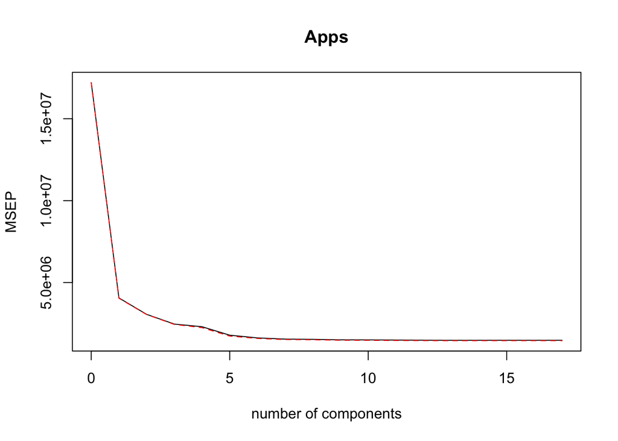

```r
validationplot(pls.fit,val.type="MSEP")
```

```r
pls.pred<-predict(pls.fit,test_set,ncomp=13)
pls.err<-mean((pls.pred-test_set$Apps)^2)
pls.err
```

```
## [1] 1106423
```

7. Comment on the results obtained. How accurately can we pre- dict the number of college applications received? Is there much difference among the test errors resulting from these five ap- proaches?

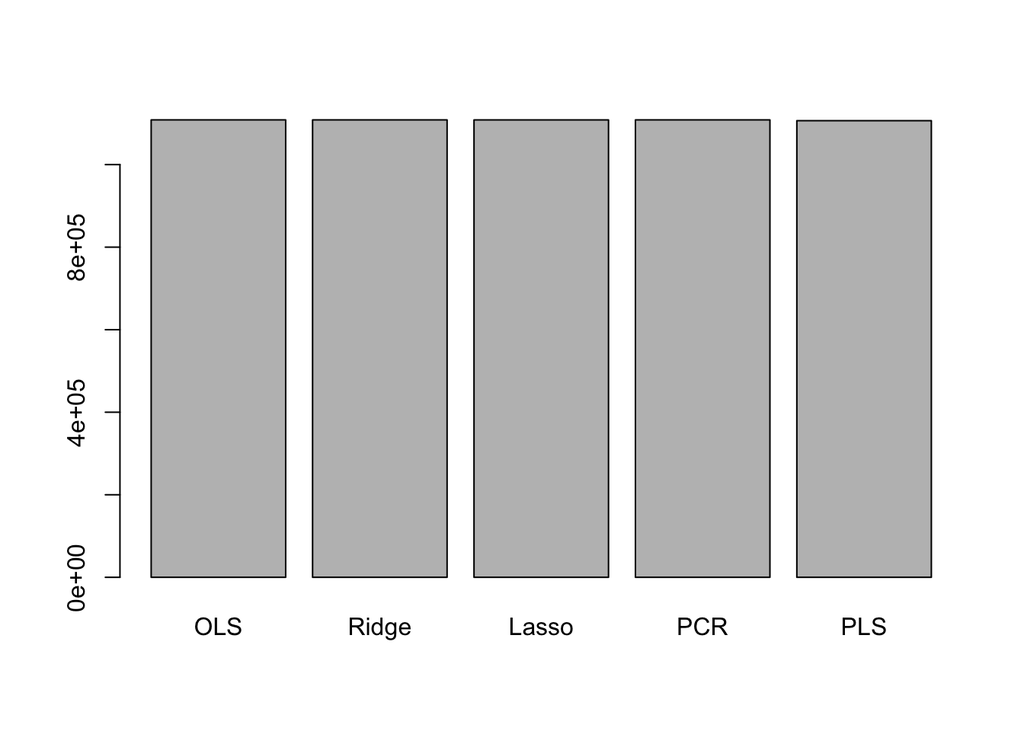

```r
error_list<-data.frame(Model=c("OLS","Ridge","Lasso","PCR","PLS"),CV_MSE=c(lm.err,ridge.err,lasso.err,pcr.err,pls.err))

barplot(error_list$CV_MSE,names.arg=error_list$Model)
```

There is not a significant difference among the model test errors. Models can generally predict the number of applicants to within ~1050 applications.